# Lab #1 - Introduction to `R`

### Indexing

Suppose we have a vector “x” and would like to extract the element in its second position and assign it to a new object called “b”:

```r
x <- 5:10
b <- x[2]
b
```

```
## [1] 6
```

The square brackets, `[` and `]`, are used to *access* a certain position (or multiple positions) within an object. In this example we access the second position of the object “x”.

Some objects, such as data frames, have multiple dimensions, requiring indices in each dimension (separated by commas) to describe a single element. A few examples are shown below:

```r
DF <- data.frame(x = x, y = y, z = z)
DF[2,3] # The element in row 2, column 3
```

```
## [1] "B"
```

```r
DF[2,] # Everything in row 2
```

```
##   x y z
## 2 6 2 B
```

For list objects, double square brackets, `[[`, are used to access positions within the list:

```r
my_list[[2]] ## The 2nd component of the list
```

```
##   A B C
## 1 1 1 A
## 2 2 2 B
## 3 3 3 C
```

**Question #3**: Use indices to print the Happiness score (column #3) of Hong Kong (row #57) in the object `my_data` (the Happy Planet data from Question #1). Be sure your code does not print any other information about this observation.

$~$

### Working with Data

Suppose we want to access a single variable from a data set, there are a few different ways we can do so:

```r
# The $ accesses the component named 'Country' within 'my_data'
countries <- my_data$Country

# Position indexing to access the variable 'Country' (since its the first column)
countries2 <- my_data[,1]

# Use the name of the variable in place of an index position
countries3 <- my_data[,'Country']
```

Suppose we want to access a single observation (data point) in our dataset:

```r
Albania <- my_data[1,] # This stores the entire first row
```

Suppose we want a range of observations:

```r
FirstFive <- my_data[1:5,] # This stores the first five rows
head(FirstFive)
```

```
##     Country Region Happiness LifeExpectancy Footprint  HLY   HPI HPIRank
## 1   Albania      7       5.5           76.2       2.2 41.7 47.91      54
## 2   Algeria      3       5.6           71.7       1.7 40.1 51.23      40
## 3    Angola      4       4.3           41.7       0.9 17.8 26.78     130
## 4 Argentina      1       7.1           74.8       2.5 53.4 58.95      15
## 5   Armenia      7       5.0           71.7       1.4 36.1 48.28      48
##   GDPperCapita   HDI Population
## 1         5316 0.801       3.15
## 2         7062 0.733      32.85
## 3         2335 0.446      16.10
## 4        14280 0.869      38.75
## 5         4945 0.775       3.02
```

The `head` function prints the first few rows and variables of an object. Here are a few other functions might use when working with a new data set:

```r
dim(my_data) # prints the dimensions of 'my.data'
```

```
## [1] 143  11
```

```r
nrow(my_data) # prints the number of rows of 'my.data'
```

```
## [1] 143
```

```r
ncol(my_data) # prints the number of columns of 'my.data'
```

```
## [1] 11
```

```r
colnames(my_data) # prints the names of the variables (columns) of 'mydata'
```

```
##  [1] "Country"        "Region"         "Happiness"      "LifeExpectancy"
##  [5] "Footprint"      "HLY"            "HPI"            "HPIRank"
##  [9] "GDPperCapita"   "HDI"            "Population"
```

**Question #4 (Part A)**: Write code that prints the populations of the last three observations (countries) that appear in the Happy Planet data.

**Question #4 (Part B)**: Write code that finds the median value of the “LifeExpectancy” variable *for the last 10 observations* in the Happy Planet data.

$~$

### Logical Conditions and Subsetting

Often we want to access all data that meet certain criteria. For example, we may want to analyze all countries with a life expectancy above 80. To accomplish this, we’ll need to use logical operators:

```r
## This returns a logical vector using the condition "> 80"
my_data$LifeExpectancy > 80
```

A few logical operators you should know of are:

| Operator | Description |
| --- | --- |
| `==` | equal to |
| `!=` | not equal to |
| `>` | great than |
| `>=` | greater than or equal to |
| `<` | less than |
| `<=` | less than or equal to |
| `&` | and |
| `\|` | or |
| `!` | negation (“not”) |

The `which()` function can be used to identify the indices of elements of within an object containing the logical value `TRUE`, for example:

```r
## This returns the positions where the condition evaluated to TRUE
which(my_data$LifeExpectancy > 80 )
```

This result could then be used as indices to subset `my_data`:

```r
## sub-setting via indices
keep_idx <- which(my_data$LifeExpectancy > 80)
my_subset <- my_data[keep_idx, ]
```

The approach shown above is a bit cumbersome. As an alternative we can use the `subset()` function alongside logical expressions:

```r
## Example #1
Ex1 <- subset(my_data, LifeExpectancy > 80)
```

In example #1, the data frame `Ex1` will contain the subset of countries with life expectancy above 80. Notice how the `subset()` function knows that `LifeExpectancy` is a component of `my_data`.

```r
## Example #2
Ex2 <- subset(my_data, LifeExpectancy <= 70 & Happiness > 6)
```

In example #2, the `&` operator is used to create a data frame, `Ex2`, containing all countries with a life expectancy of 70 or below *and* a happiness score above 6.

```r
## Example #3
Ex3 <- subset(my_data, LifeExpectancy <= 70 | Happiness > 6)
```

In example #3, the `|` operator is used create a data frame of all countries with a life expectancy of 70 or below *or* a happiness score above 6. Notice the different dimensions of `Ex2` and `Ex3`:

```r
dim(Ex2)
```

```
## [1]  9 11
```

```r
dim(Ex3)
```

```
## [1] 118  11
```

**Question #5**: Create a data frame named “Q5” that contains all countries with a population over 100 million that also have a happiness score of 6 or lower. Then, print the number of rows of this data frame.

$~$

### Data Summaries

Descriptive summaries are an essential component of any data analysis. A few functions used to calculate several basic numerical summaries are shown below:

```r
mean(my_data$LifeExpectancy) # mean
```

```
## [1] 67.83846
```

```r
sd(my_data$LifeExpectancy) # standard deviation
```

```
## [1] 11.04193
```

```r
min(my_data$LifeExpectancy) # minimum
```

```
## [1] 40.5
```

```r
max(my_data$LifeExpectancy ) # maximum
```

```
## [1] 82.3
```

```r
quantile(my_data$LifeExpectancy, probs = .35) # the 35th percentile
```

```
##   35%
## 66.18
```

Each of these functions operates on a single variable. For a broader set of summary statistics, you can input an entire data frame into the `summary()` function:

```r
summary(my_data)
```

```
##    Country              Region        Happiness     LifeExpectancy
##  Length:143         Min.   :1.000   Min.   :2.400   Min.   :40.50
##  Class :character   1st Qu.:2.000   1st Qu.:5.000   1st Qu.:61.90
##  Mode  :character   Median :4.000   Median :5.900   Median :71.50
##                     Mean   :3.832   Mean   :5.919   Mean   :67.84
##                     3rd Qu.:6.000   3rd Qu.:7.000   3rd Qu.:76.05
##                     Max.   :7.000   Max.   :8.500   Max.   :82.30
##
##    Footprint           HLY             HPI           HPIRank
##  Min.   : 0.500   Min.   :11.60   Min.   :16.59   Min.   :  1.0
##  1st Qu.: 1.300   1st Qu.:31.10   1st Qu.:34.47   1st Qu.: 36.5
##  Median : 2.200   Median :41.80   Median :43.60   Median : 72.0
##  Mean   : 2.877   Mean   :41.38   Mean   :43.38   Mean   : 72.0
##  3rd Qu.: 3.850   3rd Qu.:53.20   3rd Qu.:52.20   3rd Qu.:107.5
##  Max.   :10.200   Max.   :66.70   Max.   :76.12   Max.   :143.0
##
##   GDPperCapita        HDI           Population
##  Min.   :  667   Min.   :0.3360   Min.   :   0.290
##  1st Qu.: 2107   1st Qu.:0.5790   1st Qu.:   4.455
##  Median : 6632   Median :0.7720   Median :  10.480
##  Mean   :11275   Mean   :0.7291   Mean   :  44.145
##  3rd Qu.:15711   3rd Qu.:0.8680   3rd Qu.:  31.225
##  Max.   :60228   Max.   :0.9680   Max.   :1304.500
##  NA's   :2       NA's   :2
```

Notice how `summary()` is not particularly useful *categorical variables*. For these variables you should be using *frequency tables*.

A *one-way frequency table* shows the frequencies of categories in a single categorical variable, while a *two-way frequency tables* shows the relationship between two categorical variables. Both are created by the `table()` function:

```r
table(my_data$Region) # A one-way frequency table of 'region'
```

```
##
##  1  2  3  4  5  6  7
## 24 24 16 33  7 12 27
```

```r
table(my_data$Region, my_data$LifeExpectancy > 80) # A two-way frequency table showing the number of countries w/ LifeExpectancy > 80 by region
```

```
##
##     FALSE TRUE
##   1    24    0
##   2    16    8
##   3    15    1
##   4    33    0
##   5     7    0
##   6    10    2
##   7    27    0
```

```r
# Notice how the table function can use numeric, logical, and character variables
```

Tables are their own type of object, and they can be used as an input to functions like `barplot()`:

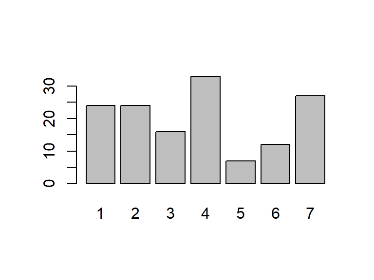

```r
my_table <- table(my_data$Region) # Tables can be stored as objects
barplot(my_table) # Creates a bar plot from a table
```

They can also be used as an input to the `prop.table()` function to find row or column proportions:

```r
prop.table(my_table, margin = 1) # "margin = 1" gives row props, "margin = 2" gives column props
```

```
##
## 1 2 3 4 5 6 7
## 1 1 1 1 1 1 1
```

In the example above, the table only had a single dimension (so each row total was the same as the frequency). Shown below is a more typical example:

```r
my_table <- table(my_data$Region, my_data$LifeExpectancy > 80)
prop.table(my_table, margin = 1)
```

```
##
##         FALSE      TRUE
##   1 1.0000000 0.0000000
##   2 0.6666667 0.3333333
##   3 0.9375000 0.0625000
##   4 1.0000000 0.0000000
##   5 1.0000000 0.0000000
##   6 0.8333333 0.1666667
##   7 1.0000000 0.0000000
```

Notice how this example used a logical condition to construction a binary variable to serve as the columns in the table.

**Question #6**: Find the mean, median, and range (maximum - minimum) of the variable `LifeExpectancy` in the Happy Planet data. Briefly comment on whether the distribution of this variable seems to be symmetric or skewed using plain text beneath your answer’s code chunk.

$~$

### Practice (required)

*The College Scorecard* is a government database that record various characteristics of accredited colleges and universities within the United States. A portion of this database containing 2019-2020 data on colleges that primarily award undergraduate degrees and had at least 400 full time students is available at the URL below:

https://remiller1450.github.io/data/Colleges2019.csv

You will use these data in Question #7 (below).

**Question #7**:

- **Part A**: Load these data into `R` and store them as a data.frame object named `colleges`.
- **Part B**: Create a subset of `colleges` that admit fewer than 25% of applicants (as measured by “Adm_Rate”). Store this subject in an object named `colleges_selective`.
- **Part C**: Using the subset you created in Part B, `colleges_selective`, construct a table containing the proportion of private colleges within each region.
- **Part D**: Provide a 1-sentence interpretation of one of the proportions in your table (you may choose which one seems most interesting).